# NPP, GPP, and Rh Processing and Inital Analysis

## Input Data

```r
# I wanted to use data.table but there were issues with the grouping by and aggregating.
library(dplyr)
library(tidyr)
library(ggplot2)
library(magrittr)
library(data.table)
library(lubridate)
library(tibble)
# install.packages('udunits2')
# Where to save the results.
out_dir <- here::here('JJ_projects', 'data'); dir.create(out_dir, showWarnings = FALSE)
# Import the data, only look at the values of Rh.
raw_data <- read.csv('~/Documents/PNNL/landmodels/extdata/yr_latlon_fldmean.csv', stringsAsFactors = FALSE)
# Subset the data so  that it only contains data from the years we are intrested in.
raw_data <- raw_data[raw_data$year %in% 1980:2015, ]
# It looks like CNRM-CM6-1 reports the units in kg CO2 while the other models reported the values in kg of C.
# Convert the CNRM-CM6-1 output to be consistent with the other models.
raw_data <- as.data.table(raw_data)
raw_data <- raw_data[model == "CNRM-CM6-1" & variable %in% c('rh', 'npp'), value := value * (12.0107/44.01)]
raw_data <- raw_data[model == "CNRM-CM6-1-HR" & variable %in% c('rh', 'npp'), value := value * (12.0107/44.01)]
raw_data <- as_tibble(raw_data)
```

### Format and Quality Check

Take care of NA values.

```
[1] 36096
```

Because the lat and lon coordinates are formatted funky we are going to want to modify them so that they are easier to work with.

```r
# Create a latitude column, start by parsing out the coordinate information
# from the cdo argument column and format as a matrix.
coords <- strsplit(gsub(pattern = '-sellonlatbox,', replacement = '', x = raw_data$cdo_arg), split = ',')
coords <- matrix(unlist(coords), nrow = length(coords), byrow = TRUE)[,3]
raw_data[['coords']] <- as.numeric(coords)
```

Save a data frame of the area per coordinates.

```r
df_area_coords <- raw_data[ , names(raw_data) %in% c("raw_data", "experiment", "model", "coords", "area", "units")]
df_global_area <- df_area_coords %>%
  group_by(model, experiment) %>%
  summarise(area = sum(area)) %>%
  ungroup()
```

Calculate the annual mean flux, in theory the dimensions should not change because this is annual data. This is a precautionary step just incase the results for a single year were split over mulitple files.

```r
raw_data %>%
  group_by(year, variable, experiment, ensemble, model, coords, units) %>%
  summarise(value = mean(value)) %>%
  ungroup(.) ->
  annual_mean
```

Since the units are currently the average kg C m^-2 s^-1 for a year let's convert them to g C m^-2 yr^-1

```r
# First multiply the rate by the number of seconds in a year.
annual_mean$value <- annual_mean$value * 3.154e7

# Now convert from kg to g.
annual_mean$value <- udunits2::ud.convert(x = annual_mean$value, u1 = 'kg', u2 = 'g')
annual_mean$units <- gsub(x = annual_mean$units, pattern = "s-1", replacement = "yr-1")
```

Calculate the global rate.

| year | variable | experiment | ensemble | model | units | value |
| --- | --- | --- | --- | --- | --- | --- |
| 1980 | gpp | historical | r10i1p1f1 | CESM2 | kg m-2 yr-1 | 21895.501 |
| 1980 | gpp | historical | r10i1p1f1 | INM-CM5-0 | kg m-2 yr-1 | 29249.615 |
| 1980 | gpp | historical | r10i1p1f1 | IPSL-CM6A-LR | kg m-2 yr-1 | 22838.616 |
| 1980 | gpp | historical | r10i1p1f1 | MPI-ESM1-2-LR | kg m-2 yr-1 | 27681.696 |
| 1980 | gpp | historical | r10i1p1f1 | NorCPM1 | kg m-2 yr-1 | 17408.665 |
| 1980 | gpp | historical | r10i1p1f2 | CNRM-CM6-1 | kg m-2 yr-1 | 23511.395 |
| 1980 | gpp | historical | r10i1p1f2 | CNRM-ESM2-1 | kg m-2 yr-1 | 20325.309 |
| 1980 | gpp | historical | r11i1p1f1 | CESM2 | kg m-2 yr-1 | 22565.073 |
| 1980 | gpp | historical | r11i1p1f1 | IPSL-CM6A-LR | kg m-2 yr-1 | 22314.686 |
| 1980 | gpp | historical | r11i1p1f1 | NorCPM1 | kg m-2 yr-1 | 17671.181 |

[output cut: 990 more lines]

Make some diagnositc plots to make sure that. The results make sense and are consistent.

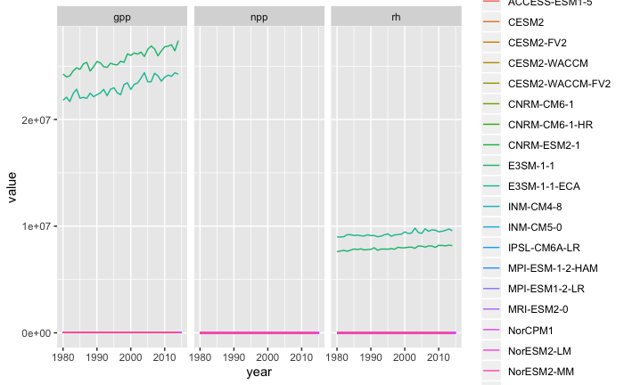

```r
global_mean %>%
  ggplot() +
  geom_line(aes(year, value, color = model, group = interaction(ensemble,  variable, model))) +
  facet_wrap('variable')
```

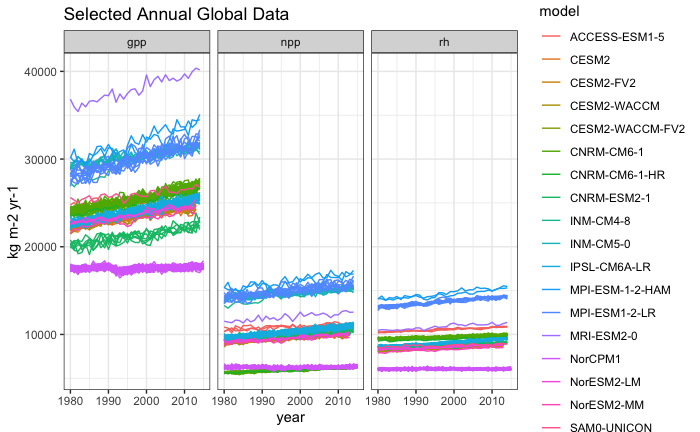

```r
global_mean %>%
  mutate(keep  = if_else(variable == 'gpp' & model %in% c("E3SM-1-1", "E3SM-1-1-ECA"), FALSE, TRUE)) %>%
  mutate(keep = if_else(variable == 'rh' & model %in% c("E3SM-1-1", "E3SM-1-1-ECA"), FALSE, keep)) %>%
  filter(keep) %>%
  select(-keep) %>%
  filter(value > -1) ->
  clean_global_data

clean_global_data %>%
  ggplot() +
  geom_line(aes(year, value, color = model, group = interaction(ensemble,  variable, model))) +
  facet_wrap('variable') +
  labs(title = 'Selected Annual Global Data', y = "kg m-2 yr-1") +
  theme_bw()
```

[output not shown]

[output cut: 990 more lines]

Make a quick plot of the lat / lon data for a single year.

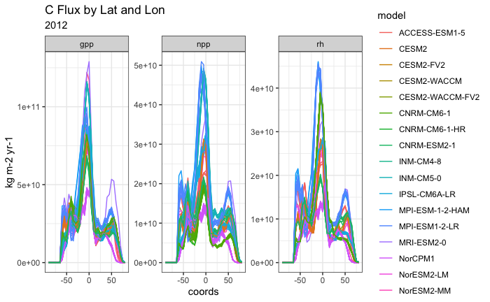

```r
clean_laltlon_data %>%
  filter(year == '2012') %>%
  ggplot(aes(coords, value, color = model, group = interaction(model, ensemble))) +
  geom_line() +
  facet_wrap('variable', scales = 'free') +
  labs(title = 'C Flux by Lat and Lon', subtitle = '2012', y = "kg m-2 yr-1") +
  theme_bw()
```

## Calculate the Percent of Global Total.

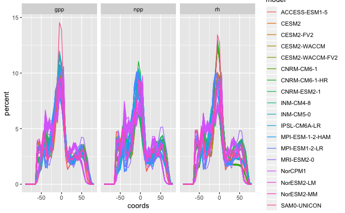

## Format

Now that our data looks decent let's save the data. For simplicity's sake let's save a copy of each of the time series by variable.

| year | variable | experiment | ensemble | model | units | value |
| --- | --- | --- | --- | --- | --- | --- |
| 1980 | gpp | historical | r10i1p1f1 | CESM2 | kg m-2 yr-1 | 6.905841e+11 |
| 1980 | gpp | historical | r10i1p1f1 | INM-CM5-0 | kg m-2 yr-1 | 9.225329e+11 |
| 1980 | gpp | historical | r10i1p1f1 | IPSL-CM6A-LR | kg m-2 yr-1 | 7.203300e+11 |
| 1980 | gpp | historical | r10i1p1f1 | MPI-ESM1-2-LR | kg m-2 yr-1 | 8.730807e+11 |
| 1980 | gpp | historical | r10i1p1f1 | NorCPM1 | kg m-2 yr-1 | 5.490693e+11 |
| 1980 | gpp | historical | r10i1p1f2 | CNRM-CM6-1 | kg m-2 yr-1 | 7.415494e+11 |
| 1980 | gpp | historical | r10i1p1f2 | CNRM-ESM2-1 | kg m-2 yr-1 | 6.410603e+11 |
| 1980 | gpp | historical | r11i1p1f1 | CESM2 | kg m-2 yr-1 | 7.117024e+11 |
| 1980 | gpp | historical | r11i1p1f1 | IPSL-CM6A-LR | kg m-2 yr-1 | 7.038052e+11 |
| 1980 | gpp | historical | r11i1p1f1 | NorCPM1 | kg m-2 yr-1 | 5.573490e+11 |

[output cut: 990 more lines]

Next save a copy of the raw lat and lon values.

Save information about the area per sampled region.